# Title

Keisuke Atsumi

20/09/06 18:56

```r
rm(list=ls())  # reset workspace
options(scipen=100)  # do not show numbers using exponential

# install & load packages
pacman::p_load(
  openxlsx   # open excel
  , tidyverse
  , magrittr   # extended pipe
  , MCMCglmm   # comparative analysis
  , rotl       # open tree of life
  , ape        # Phylogeny
  , phytools   # Phylogeny
  , knitr
  , kableExtra # nice tables
  , pander     # nice tables
  , ggtree
  # , R.rsp
)

# Rmarkdown settings
knitr::opts_chunk$set(
  prompt  = FALSE,  # Do not add > or + in inline-code
  message = FALSE,
  comment = "",
  warning = FALSE,  # Mute warnings
  tidy    = TRUE
  )
options(knitr.kable.NA = '') # Hide NAs in kable table

## Phenotype data ##
pheno <- read.xlsx(
    "../data/original.data.xlsx", sheet = "Phenotype"
    ) %>%
  # Excluding data without any parent data
  drop_na(contains("SD.sp")) %>%
  # to numeric
  mutate_at(
    vars(contains("Mn") | contains("SD") | N.sp1:N.sp2),
    as.numeric
    ) %>%
  # delete observation with negative mean trait value
  filter(Mn.sp1 > 0 & Mn.sp2 > 0 & homologous == "Yes") %>%
  # calculate phenotypic difference between parental species
  mutate(
    Pheno.divergence = abs(log(Mn.sp1/Mn.sp2))
    ) %>%
  mutate_at(vars(contains("pheno.div")), scale) %>%
  # describe whether full cross or not
  mutate(
    Reciprocal = ifelse(
      is.na(Mn.hyb12 & Mn.hyb21),
      "Inviable", "Viable"
      )
    )
meta <- read.xlsx(
    "../data/original.data.xlsx", sheet = "Metadata"
    ) %>%
  mutate_at(vars(contains("divergence")), as.numeric) %>%
  # Logalize genetic divergence
  mutate_at(vars(contains("divergence")), log10)

original.dat <- left_join(pheno, meta)
# add unique ID for each effect size (row)
original.dat$ES.ID <- paste("ES", sprintf("%03d",c(1:dim(original.dat)[1])), sep="")
```

# d<sub>mismatch</sub> calculation

Following [Thompson 2019](https://www.biorxiv.org/content/10.1101/818658v1.full#disp-formula-1), d<sub>mismatch</sub> calculation has two important part:

**Standardizing hybrid trait value using parent trait value**  
Standardized hybrid trait value in trait $i$, $Z_i$ is  
$Z_i = \frac{hyb_i - spSS_i}{spLL_i - spSS_i}$  
This will put hybrid trait mean to 0-1, if not transgressed. But, this standardised value is sensitive to absolute trait size: large trait size with relatively small parental phenotypic divergence, transgressive hybrid phenotype will be scored as quite large *standardized* trait value. This seems occurred in mice (see bellow)

**Calculate d<sub>mismatch</sub>**  
$d_{mismatch} = \sqrt{2} * \sqrt{ Z_i^2 + Z_j^2 - \frac{Z_i + Z_j}{\sqrt{2}}^2 }$ eqn 2 and 4 in [Thompson 2019](https://www.biorxiv.org/content/10.1101/818658v1.full#disp-formula-1).

```r
dat <- original.dat %>%
  select(Study.ID, Cross.ID, taxa, Genus, Reciprocal, contains("Mn")) %>%
  # Gather reciprocal hybrid data
  gather(
    key = Hybrid, value = Mn.hybrid,
    -c(Study.ID, Cross.ID, taxa, Genus, Reciprocal), -contains("Mn.sp")
    ) %>%
  drop_na(Mn.hybrid) %>%
  # Calculate standardized hybrid phenotype mean *** important part ***
  mutate(
    Dominance = ifelse(
      Mn.sp1 > Mn.sp2,
      (Mn.hybrid - Mn.sp2)/abs(Mn.sp1 - Mn.sp2),
      (Mn.hybrid - Mn.sp1)/abs(Mn.sp1 - Mn.sp2)
    )
  ) %>%
  mutate_at("Cross.ID", as.factor) %>%
  arrange(taxa, Genus, Cross.ID, Hybrid) %>%
  # only get crosses with > 2 traits
  # Reciprocal hybrids are separated
  group_by(Cross.ID, Hybrid, taxa, Genus, Study.ID, Reciprocal) %>%
  filter(n() > 2) %>%
  # Create all combinations of standardized hybrid phenotype mean
  do(data.frame(t(combn(.$Dominance, 2)))) %>%
  # Calculate dominance mismatch *** important part ***
  mutate(
    Mismatch = sqrt(2) * sqrt( X1^2 + X2^2 - ( (X1 + X2) / sqrt(2) )^2 ),
    Mismatch.log = log(Mismatch)
  ) %>%
  left_join(meta) %>%
  mutate_if(is.character, as.factor) %>%
  within(taxa <- ordered(taxa, levels = c("Neuroptera", "Coleoptera", "Diptera", "Lepidoptera", "Orthoptera", "Aves", "Rodentia", "Anura", "Cichliformes"))) %>%
  as.data.frame

dat %>%
  summarise(
    'Trait combination' = length(X1),
    'Species pair' = length(unique(species.pair)),
    'Crossing' = length(unique(Cross.ID))
    ) %>%
  kable("html") %>% kable_styling("striped", position = "left")
```

| Trait combination | Species pair | Crossing |
| --- | --- | --- |
| 15107 | 20 | 27 |

# Plot d<sub>mismatch</sub>

d<sub>mismatch</sub> is quite large in crossing involving mices (musculus), due to large trait value

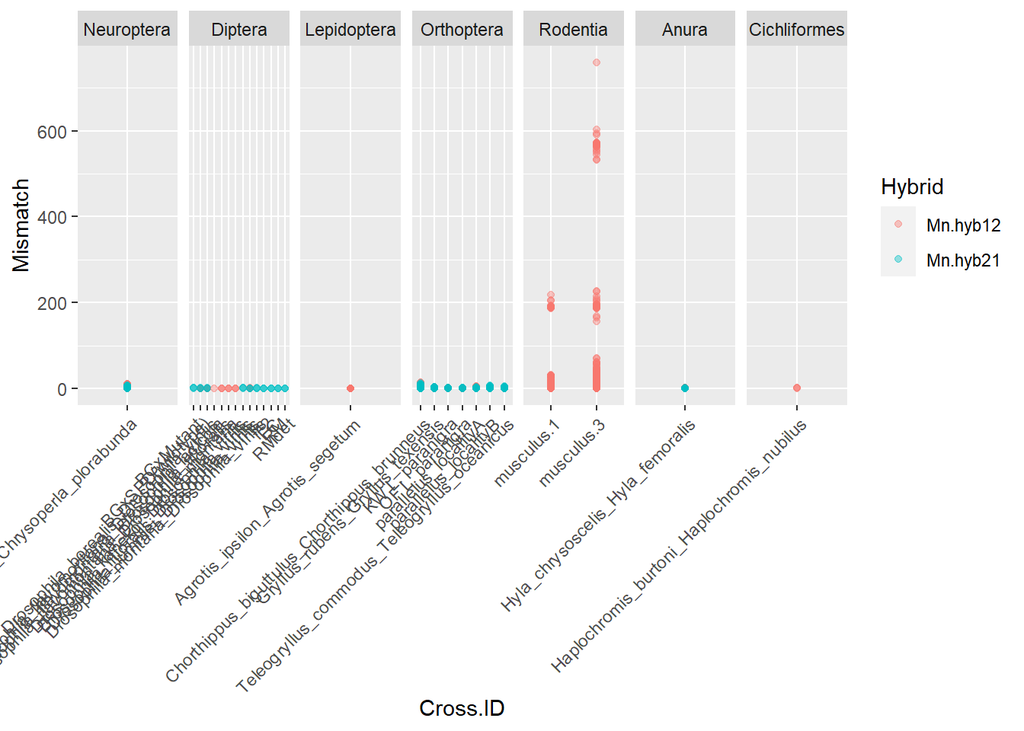

```r
ggplot(data = dat, aes(x = Cross.ID, y = Mismatch)) +
  geom_point(alpha = 0.4, aes(color = Hybrid)) +
  theme(axis.text.x = element_text(angle = 45, hjust = 1)) +
  facet_grid(~taxa, scales = "free")
```

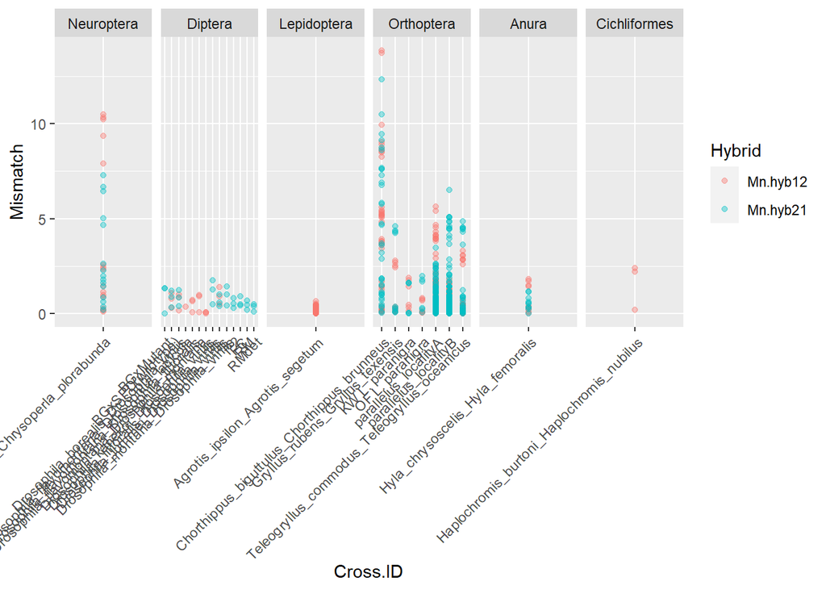

```r
ggplot(
  data = dat %>%
    filter(!grepl("musculus", Cross.ID)),
  aes(x = Cross.ID, y = Mismatch)) +
  geom_point(alpha = 0.4, aes(color = Hybrid)) +
  theme(axis.text.x = element_text(angle = 45, hjust = 1)) +
  facet_grid(~taxa, scales = "free")
```

log(d<sub>mismatch</sub>) looking good

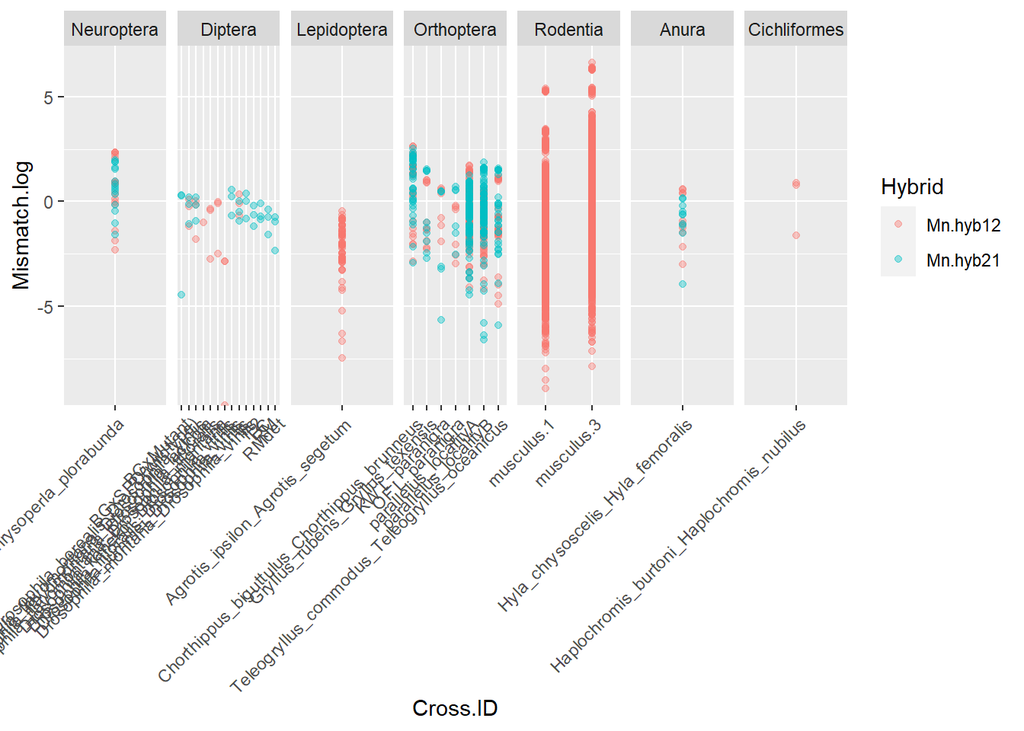

```r
ggplot(data = dat, aes(x = Cross.ID, y = Mismatch.log)) +
  geom_point(alpha = 0.4, aes(color = Hybrid)) +
  theme(axis.text.x = element_text(angle = 45, hjust = 1)) +
  facet_grid(~taxa, scales = "free")
```

# Analyze d<sub>mismatch</sub>

Conducted MCMCglmm employing Gaussian distribution for raw d<sub>mismatch</sub> and log(d<sub>mismatch</sub>).  
Included study (`Study.ID`), phylogeny (`sp1.name`), crossed strain (`Cross.ID`) and cross direction (`Hybrid`) as random effects. SE was not taken into account.

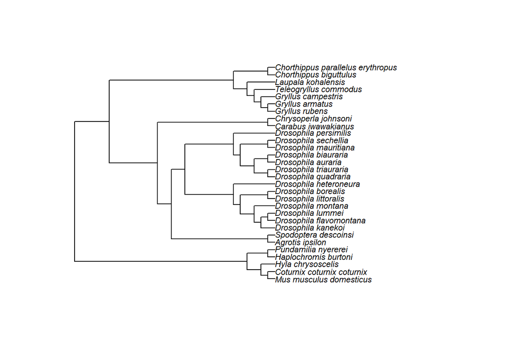

```r
#++++++++++++++++++++++++++++++++++#
# Phylogenetic tree for mcmcglmm
#++++++++++++++++++++++++++++++++++#

# compute branch lengths of tree
phylo_branch <- read.tree(file = "../data/phylo.novelty.tre") %>%
  compute.brlen(method = "Grafen", power = 1)
plot.phylo(phylo_branch, cex = 0.7)
```

```r
# # saving phylogeneic matrix
# phylo_cor <- vcv(phylo_branch, cor = T)
#
# # generating inverse phylogenetic matrix for MCMCglmm
# phylo_branch$node.label <- NULL
# phylo_MCMC <- MCMCglmm::inverseA(phylo_branch, nodes = "ALL", scale = TRUE)$Ainv

dat2 <- drop_na(dat, Mismatch.log)

# ### Log mismatch data ###

# ### Mismatch data ###
# phylmix <-MCMCglmm(
#   fixed = Mismatch ~  1,
#   # idh(SE):units | weight by SE of effect size
#   random = ~ Study.ID + sp1.name + Cross.ID + Hybrid,
#   verbose = FALSE,
#   ginverse = list(sp1.name = phylo_MCMC),
#   nitt = 60000,  # Increase the number of iterations, default is 13000
#   burnin = 5000,  # Increase the number of burnin, default is 3000
#   data = dat
# )
# saveRDS(phylmix, file = "../Analysis/mismatch.obj")
```

### Log d<sub>mismatch</sub>

```r
# phylmix <-MCMCglmm(
#   fixed = Mismatch.log ~  1,
#   # idh(SE):units | weight by SE of effect size
#   random = ~ Study.ID + sp1.name + Cross.ID + Hybrid,
#   verbose = FALSE,
#   ginverse = list(sp1.name = phylo_MCMC),
#   nitt = 60000,  # Increase the number of iterations, default is 13000
#   burnin = 5000,  # Increase the number of burnin, default is 3000
#   data = dat2
# )
# saveRDS(phylmix, file = "../Analysis/mismatch.log.obj")

phylmix <- readRDS("../Analysis/mismatch.log.obj")

### Fixed effects output ###
summary(phylmix)$solutions %>%
  kable("html") %>% kable_styling("striped", position = "left")
```

|  | post.mean | l-95% CI | u-95% CI | eff.samp | pMCMC |
| --- | --- | --- | --- | --- | --- |
| (Intercept) | 1125.967 | -192535.2 | 192760.7 | 5500 | 0.9861818 |

Yielded obviously wrong (too large) estimates. Prior, which is default, may be wrong.

### Raw d<sub>mismatch</sub>

Overall strength of mismatch

```r
# phylmix <-MCMCglmm(
#   fixed = Mismatch ~  1,
#   # idh(SE):units | weight by SE of effect size
#   random = ~ Study.ID + sp1.name + Cross.ID + Hybrid,
#   verbose = FALSE,
#   ginverse = list(sp1.name = phylo_MCMC),
#   nitt = 60000,  # Increase the number of iterations, default is 13000
#   burnin = 5000,  # Increase the number of burnin, default is 3000
#   data = dat
# )
# saveRDS(phylmix, file = "../Analysis/mismatch.obj")

phylmix <- readRDS("../Analysis/mismatch.obj")

### Fixed effects output ###
summary(phylmix)$solutions %>%
  kable("html") %>% kable_styling("striped", position = "left")
```

|  | post.mean | l-95% CI | u-95% CI | eff.samp | pMCMC |
| --- | --- | --- | --- | --- | --- |
| (Intercept) | 4.406623 | -3.048458 | 10.2854 | 770.626 | 0.166 |

```r
### Random effects output ###
summary(phylmix$VCV)$statistics %>%
  as.data.frame %>%
  kable("html", digits = 3, caption = "Random effects") %>%
  kable_styling("striped", position = "left")
```

Random effects

|  | Mean | SD | Naive SE | Time-series SE |
| --- | --- | --- | --- | --- |
| Study.ID | 1.180 | 9.214 | 0.291 | 0.456 |
| sp1.name | 8.314 | 28.882 | 0.913 | 3.148 |
| Cross.ID | 42.584 | 25.264 | 0.799 | 0.845 |
| Hybrid | 28.137 | 399.046 | 12.619 | 20.136 |
| units | 2801.555 | 31.273 | 0.989 | 0.989 |

Even data included quite large d<sub>mismatch</sub>, overall it did not differ from 0. But the estimate (ca. 4) is still much larger than Thompson et al reporting mean d<sub>mismatch</sub> is 0.6. This is presumably because transgression (novel phenotype expression), which should increase d<sub>mismatch</sub>, is much more frequent in our data compared to Thompson et al.

### Raw mismatch for each cross

```r
# phylmix <-MCMCglmm(
#   fixed = Mismatch ~ Cross.ID -1,
#   # idh(SE):units | weight by SE of effect size
#   random = ~ Study.ID + sp1.name + Hybrid,
#   verbose = FALSE,
#   ginverse = list(sp1.name = phylo_MCMC),
#   nitt = 60000,  # Increase the number of iterations, default is 13000
#   burnin = 5000,  # Increase the number of burnin, default is 3000
#   data = dat
# )
# saveRDS(phylmix, file = "../Analysis/mismatch.eachcross.obj")

phylmix <- readRDS("../Analysis/mismatch.eachcross.obj")

### Fixed effects output ###
left_join(
  # corrected estimates & SD
  summary(phylmix$Sol)$statistics %>%
    as.data.frame() %>%
    rownames_to_column(var = "Cross.ID"),
  # P
  summary(phylmix)$solutions %>%
  as.data.frame() %>%
    rownames_to_column(var = "Cross.ID"),
  by = "Cross.ID"
  ) %>%
  mutate(significance = ifelse(pMCMC < 0.05, "*", "")) %>%
  within(
    Cross.ID <- str_remove_all(Cross.ID, "Cross.ID")
    ) %>%
  right_join(
    original.dat %>%
      select(taxa, species.pair, Cross.ID) %>%
      distinct_all(),
    .
  ) %>%
  within(taxa <- ordered(taxa, levels = c("Neuroptera", "Coleoptera", "Diptera", "Lepidoptera", "Orthoptera", "Aves", "Rodentia", "Anura", "Cichliformes"))) %>%
  as.data.frame %>%
  arrange(taxa, species.pair) %>%
  kable("html", digits = 3, caption = "Fixed effects") %>%
  kable_styling("striped", position = "left")
```

Fixed effects

| taxa | species.pair | Cross.ID | Mean | SD | Naive SE | Time-series SE | post.mean | l-95% CI | u-95% CI | eff.samp | pMCMC | significance |
| --- | --- | --- | --- | --- | --- | --- | --- | --- | --- | --- | --- | --- |
| Neuroptera | Chrysoperla_johnsoni_Chrysoperla_plorabunda | Chrysoperla_johnsoni_Chrysoperla_plorabunda | 21.530 | 2795.840 | 37.699 | 26.649 | 21.530 | -2468.930 | 2775.576 | 11007.237 | 0.843 |  |
| Diptera | Drosophila_borealis_Drosophila_virilis | Drosophila_borealis_Drosophila_virilis | 41.700 | 2400.535 | 32.369 | 34.117 | 41.700 | -2439.089 | 2808.233 | 4950.799 | 0.973 |  |
| Diptera | Drosophila_flavomontana_Drosophila_lacicola | Drosophila_flavomontana_Drosophila_lacicola | 27.217 | 2489.455 | 33.568 | 34.933 | 27.217 | -2758.869 | 2231.526 | 5078.411 | 0.984 |  |
| Diptera | Drosophila_flavomontana_Drosophila_littoralis | Drosophila_flavomontana_Drosophila_littoralis | 3.150 | 2575.313 | 34.726 | 31.093 | 3.150 | -2603.914 | 2365.585 | 6859.969 | 0.997 |  |
| Diptera | Drosophila_flavomontana_Drosophila_montana | Drosophila_flavomontana_Drosophila_montana | 3.774 | 2574.713 | 34.717 | 31.103 | 3.774 | -2583.941 | 2334.977 | 6852.414 | 0.999 |  |
| Diptera | Drosophila_kanekoi_Drosophila_virilis | Drosophila_kanekoi_Drosophila_virilis | 28.311 | 2444.858 | 32.966 | 33.076 | 28.311 | -2567.150 | 2415.292 | 5463.580 | 0.996 |  |
| Diptera | Drosophila_littoralis_Drosophila_virilis | Drosophila_littoralis_Drosophila_virilis | 39.438 | 2399.605 | 32.356 | 32.975 | 39.438 | -2658.761 | 2451.720 | 5295.672 | 0.984 |  |
| Diptera | Drosophila_lummei_Drosophila_virilis | Drosophila_lummei_Drosophila_virilis | 33.209 | 2493.466 | 33.622 | 38.228 | 33.209 | -2455.633 | 2797.928 | 4254.355 | 0.990 |  |
| Diptera | Drosophila_mauritiana_Drosophila_simulans | BGxMutant | 52.010 | 2335.267 | 31.489 | 32.030 | 52.010 | -2790.795 | 1887.832 | 5315.736 | 0.965 |  |
| Diptera | Drosophila_mauritiana_Drosophila_simulans | BGxSPD(wildtype) | 50.412 | 2335.166 | 31.487 | 32.030 | 50.412 | -2784.456 | 1887.803 | 5315.225 | 0.997 |  |
| Diptera | Drosophila_montana_Drosophila_virilis | Drosophila_montana_Drosophila_virilis | 40.564 | 2437.497 | 32.867 | 37.765 | 40.564 | -2789.835 | 2137.747 | 4165.881 | 0.989 |  |
| Diptera | Drosophila_sechellia_Drosophila_simulans | FC | -1.956 | 2432.182 | 32.796 | 27.684 | -1.956 | -2417.797 | 2843.467 | 7718.358 | 0.987 |  |
| Diptera | Drosophila_sechellia_Drosophila_simulans | f^2 | -2.698 | 2431.229 | 32.783 | 27.700 | -2.698 | -2397.087 | 2828.962 | 7703.764 | 0.985 |  |
| Diptera | Drosophila_sechellia_Drosophila_simulans | RMdet | -2.795 | 2431.794 | 32.790 | 27.590 | -2.795 | -2379.154 | 2879.389 | 7768.984 | 0.997 |  |
| Diptera | Drosophila_sechellia_Drosophila_simulans | RM | -3.270 | 2431.010 | 32.780 | 27.599 | -3.270 | -2364.867 | 2854.461 | 7758.830 | 0.974 |  |
| Lepidoptera | Agrotis_ipsilon_Agrotis_segetum | Agrotis_ipsilon_Agrotis_segetum | 25.452 | 2577.950 | 34.761 | 36.933 | 25.452 | -2855.977 | 2112.036 | 4872.204 | 0.993 |  |
| Orthoptera | Chorthippus_biguttulus_Chorthippus_brunneus | Chorthippus_biguttulus_Chorthippus_brunneus | 11.619 | 2706.083 | 36.489 | 40.848 | 11.619 | -2465.720 | 2401.585 | 4388.704 | 0.706 |  |
| Orthoptera | Chorthippus_parallelus_erythropus_Chorthippus_parallelus_parallelus | parallelus_localityA | 15.934 | 2858.017 | 38.537 | 47.007 | 15.934 | -2593.876 | 2836.780 | 3696.564 | 0.872 |  |
| Orthoptera | Chorthippus_parallelus_erythropus_Chorthippus_parallelus_parallelus | parallelus_localityB | 15.863 | 2858.094 | 38.539 | 47.018 | 15.863 | -2587.865 | 2839.512 | 3695.020 | 0.887 |  |
| Orthoptera | Gryllus_rubens_Gryllus_texensis | Gryllus_rubens_Gryllus_texensis | 3.938 | 2545.378 | 34.322 | 39.414 | 3.938 | -2525.317 | 2626.121 | 4170.633 | 0.935 |  |
| Orthoptera | Laupala_kohalensis_Laupala_paranigra | KW L. paranigra | 57.618 | 2431.681 | 32.789 | 41.756 | 57.618 | -2177.335 | 3176.436 | 3391.350 | 0.948 |  |
| Orthoptera | Laupala_kohalensis_Laupala_paranigra | OF L. paranigra | 57.312 | 2431.522 | 32.787 | 41.766 | 57.312 | -2194.568 | 3168.236 | 3389.306 | 0.951 |  |
| Orthoptera | Teleogryllus_commodus_Teleogryllus_oceanicus | Teleogryllus_commodus_Teleogryllus_oceanicus | 2.148 | 3110.000 | 41.935 | 42.892 | 2.148 | -2766.597 | 2228.484 | 5257.429 | 0.925 |  |
| Rodentia | Mus_musculus_domesticus_Mus_musculus_musculus | musculus.1 | 7.433 | 2414.187 | 32.553 | 21.186 | 7.433 | -2639.269 | 2359.006 | 12985.090 | 0.471 |  |
| Rodentia | Mus_musculus_domesticus_Mus_musculus_musculus | musculus.3 | 21.968 | 2414.186 | 32.553 | 21.185 | 21.968 | -2624.289 | 2375.377 | 12985.920 | 0.365 |  |
| Anura | Hyla_chrysoscelis_Hyla_femoralis | Hyla_chrysoscelis_Hyla_femoralis | 51.174 | 3018.888 | 40.707 | 36.751 | 51.174 | -3239.421 | 2287.038 | 6747.553 | 0.984 |  |
| Cichliformes | Haplochromis_burtoni_Haplochromis_nubilus | Haplochromis_burtoni_Haplochromis_nubilus | 6.928 | 2966.759 | 40.004 | 24.966 | 6.928 | -2258.026 | 3296.219 | 14121.503 | 0.997 |  |

```r
### Random effects output ###
# transformation for estimate
# summary(phylmix$Sol/sqrt(1+c2))
# transformation for varaince
summary(phylmix$VCV)$statistics %>%
  as.data.frame %>%
  kable("html", digits = 3, caption = "Random effects") %>%
  kable_styling("striped", position = "left")
```

Random effects

|  | Mean | SD | Naive SE | Time-series SE |
| --- | --- | --- | --- | --- |
| Study.ID | 5411705.807 | 94708893.878 | 1277054.465 | 3259046.161 |
| sp1.name | 3675956.842 | 29930577.576 | 403583.826 | 2121205.397 |
| Hybrid | 535.271 | 20997.343 | 283.128 | 283.128 |
| units | 2802.714 | 32.098 | 0.433 | 0.433 |

d<sub>mismatch</sub> vary among crossings. Although d<sub>mismatch</sub>>0, several estimates were <0. Also, random effects were quite large.

### Regression for raw d<sub>mismatch</sub>

```r
dat3 <- dat %>%
  drop_na(Genet.divergence, Reciprocal, Hetero.sex, Distribution)

# phylmix <-MCMCglmm(
#   fixed = Mismatch ~  Genet.divergence + Reciprocal + Hetero.sex + Distribution,
#   # idh(SE):units | weight by SE of effect size
#   random = ~ Study.ID + sp1.name + Cross.ID + Hybrid,
#   verbose = FALSE,
#   ginverse = list(sp1.name = phylo_MCMC),
#   nitt = 60000,  # Increase the number of iterations, default is 13000
#   burnin = 5000,  # Increase the number of burnin, default is 3000
#   data = dat3
# )
# saveRDS(phylmix, file = "../Analysis/mismatch.reg.obj")

phylmix <- readRDS("../Analysis/mismatch.reg.obj")

### Fixed effects output ###
summary(phylmix)$solutions %>%
  kable("html", digits = 3) %>% kable_styling("striped", position = "left")
```

|  | post.mean | l-95% CI | u-95% CI | eff.samp | pMCMC |
| --- | --- | --- | --- | --- | --- |
| (Intercept) | -1.723 | -27.501 | 23.097 | 5500 | 0.903 |
| Genet.divergence | -1.382 | -11.559 | 8.601 | 5500 | 0.788 |
| ReciprocalViable | -8.274 | -39.102 | 19.246 | 5500 | 0.562 |
| Hetero.sexMale | 11.744 | -24.152 | 50.917 | 5500 | 0.512 |
| DistributionAllopatry | -2.588 | -31.143 | 27.310 | 5500 | 0.847 |

```r
### Random effects output ###
summary(phylmix$VCV)$statistics %>%
  as.data.frame %>%
  kable("html", digits = 3, caption = "Random effects") %>%
  kable_styling("striped", position = "left")
```

Random effects

|  | Mean | SD | Naive SE | Time-series SE |
| --- | --- | --- | --- | --- |
| Study.ID | 2.536 | 21.051 | 0.284 | 0.753 |
| sp1.name | 4.780 | 24.984 | 0.337 | 1.710 |
| Cross.ID | 60.428 | 54.181 | 0.731 | 0.800 |
| Hybrid | 259.916 | 8051.054 | 108.560 | 108.560 |
| units | 2874.717 | 33.575 | 0.453 | 0.453 |

None of species level moderators do not influence d<sub>mismatch</sub>

```r
dat4 <- dat3 %>%
  drop_na(Mismatch.log) %>%
  filter(Mismatch.log != Inf)

# phylmix <-MCMCglmm(
#   fixed = Mismatch.log ~  Genet.divergence + Reciprocal + Hetero.sex + Distribution,
#   # idh(SE):units | weight by SE of effect size
#   random = ~ Study.ID + sp1.name + Cross.ID + Hybrid,
#   verbose = FALSE,
#   ginverse = list(sp1.name = phylo_MCMC),
#   nitt = 60000,  # Increase the number of iterations, default is 13000
#   burnin = 5000,  # Increase the number of burnin, default is 3000
#   data = dat4
# )
# saveRDS(phylmix, file = "../Analysis/mismatch.reg.log.obj")

phylmix <- readRDS("../Analysis/mismatch.reg.log.obj")

### Fixed effects output ###
summary(phylmix)$solutions %>%
  kable("html", digits = 3) %>% kable_styling("striped", position = "left")
```

|  | post.mean | l-95% CI | u-95% CI | eff.samp | pMCMC |
| --- | --- | --- | --- | --- | --- |
| (Intercept) | -1997.018 | -191859.9 | 198409.0 | 6613.523 | 0.972 |
| Genet.divergence | -832.386 | -189845.9 | 195127.2 | 5500.000 | 0.996 |
| ReciprocalViable | 2057.520 | -195439.5 | 196141.7 | 5500.000 | 0.992 |
| Hetero.sexMale | 1040.418 | -189059.7 | 197441.8 | 5784.006 | 0.995 |
| DistributionAllopatry | -2383.338 | -188885.2 | 194019.8 | 5500.000 | 0.989 |

```r
### Random effects output ###
summary(phylmix$VCV)$statistics %>%
  as.data.frame %>%
  kable("html", digits = 3, caption = "Random effects") %>%
  kable_styling("striped", position = "left")
```

Random effects

[output not shown]

Model did not converge well